# Statistical Inference Simulation Project

Remember to convert to PDF after completion

### Overview:

To investigate the relationship between the exponential distribution in R and the Central Limit Theorom (CLT). There are 3 tasks:

1. Show the sample mean and compare it to the theoretical mean of the distribution.
2. Show how variable the sample is (via variance) and compare it to the theoretical variance of the distribution.
3. Show that the distribution is approximately normal. Which I hope to answer in order.

First, to provide reproducibility for the random variables used. Then we set the base characteristics that was provided by the project guideline.

```r
set.seed(3032)

lambda <- 0.2
mean=1/lambda
n<-40
nosims<-1000
data=rexp(n*nosims, lambda)
```

To simulate rexp(n, lambda) 1000 times, we will keep the data in a neat matrix. Then, to answer the first question, we will find the sample mean of this simulation and compare it with the theoretical mean (1/lambda).

```r
exD<- matrix(data,nrow=nosims)
exDmean<-apply(exD,1,mean)

##The sample mean of the simulated mean will be:
mean(exDmean)
```

```
## [1] 5.014347
```

```r
##while the theoretical mean is 1 over lambda, which is:
print(mean)
```

```
## [1] 5
```

To show it graphically, we will use a histogram, where the green dotted line is the simulated mean and the blue is the theoretical. They are almost on top of each other and might be a bit difficult to see separately, which is why I plotted the dotted line on top of the blue one.

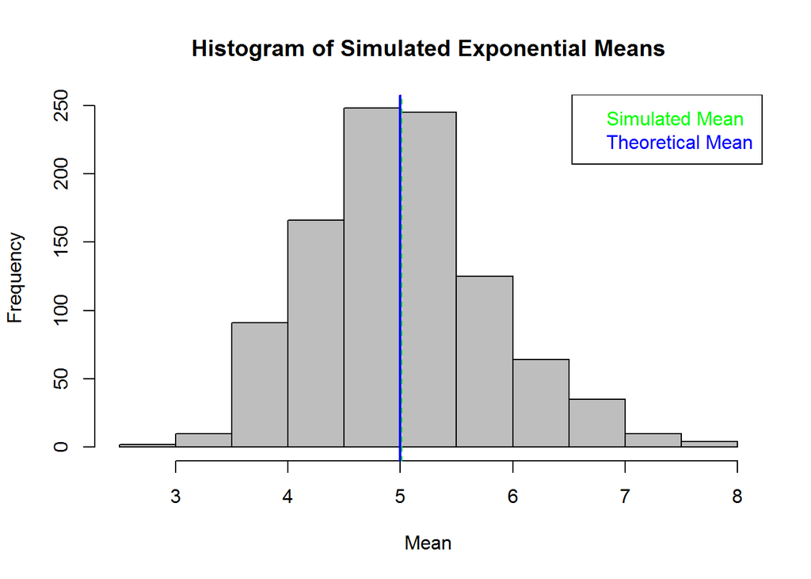

```r
hist(exDmean, xlab="Mean", main="Histogram of Simulated Exponential Means", col="grey"
     )
legend("topright", c("Simulated Mean", "Theoretical Mean"), text.col=c("green", "blue"))
abline(v=mean, col="blue", lwd=2)
abline(v=mean(exDmean),col="green", lty=2)
```

# Question 2

The varience of a probability is the square of the standard deviation (s), which also measures how far from the mean a random sample can fall. We use s to measure the variablity of the data as it uses the same unit of measurement as the original variable, and can be applied to the mean.

```r
exDsd<- sd(exDmean)

##The sample standard distribution of the simulation will be:
print(exDsd)
```

```
## [1] 0.8011365
```

```r
##while the standard distribution of the theoretical value will be
sd<-(1/lambda)/sqrt(n)

##To answer the question, we will have to find variance by applying the formula v=sd^2

var<- exDsd^2
print(var)
```

```
## [1] 0.6418196
```

```r
tvar<- sd^2
print(tvar)
```

```
## [1] 0.625
```

# Question 3: Show that the distribution is approximately normal.

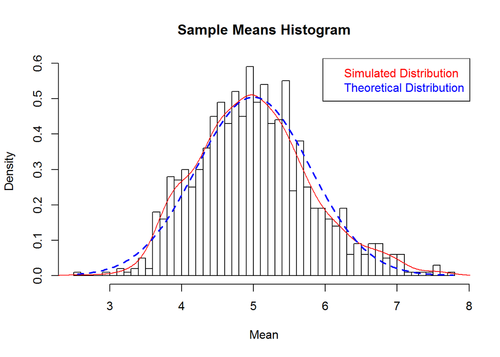

```r
hist(exDmean, breaks=40, prob=T,
     main="Sample Means Histogram", xlab="Mean")

##After drawing the histogram of the mean, showing more counts of the means than the above histogram, we will fill it with the ext-rapolated distribution lines, for both the sample as well as the theoretical.

lines(density(exDmean), col="red")

xfit<- seq(min(exDmean), max(exDmean), length=250)
yfit<- dnorm(xfit, mean, sd)
lines(xfit, yfit, pch=30,col="blue",lty=2, lwd=2)
legend("topright", c("Simulated Distribution", "Theoretical Distribution"), text.col=c("red", "blue"))
```